# Continuous Glucose Monitoring vs. Blood Glucose Monitoring in Non-Insulin-Treated Type 2 Diabetes

A reproducible meta-analysis of HbA1c outcomes

Author

Said Adjao

Published

June 18, 2026

## 1 Summary

This report synthesizes randomized evidence on continuous glucose monitoring (CGM) versus blood glucose monitoring (BGM) for glycaemic control in adults with type 2 diabetes **not treated with insulin** — a population for which CGM coverage is frequently restricted. Pooling 8 trials, CGM was associated with a mean HbA1c reduction of **-0.42%** (95% CI -0.59 to -0.25), with no detectable between-study heterogeneity (I² = 0%). The estimate is consistent with a recently published meta-analysis, supporting a modest but reliable benefit in this population.

## 2 Background

Most clinical-trial evidence and payer coverage for CGM in type 2 diabetes derives from insulin-treated populations. Whether the benefit extends to non-insulin-treated patients — the larger group, and the one typically excluded from CGM reimbursement — is a distinct question with direct cost and coverage implications. This analysis synthesizes the randomized evidence specific to that population.

## 3 Methods

### 3.1 Eligibility criteria

Randomized controlled trials were eligible if they enrolled adults with type 2 diabetes treated **exclusively with non-insulin therapies**, compared any CGM modality (intermittently scanned, real-time, or professional) against BGM or usual care, and reported HbA1c as an outcome. Trials enrolling any insulin-treated participants were excluded.

### 3.2 Information sources and study selection

The trial set was harvested from a 2025 systematic review by Aronson and colleagues that applied the same non-insulin-only inclusion criterion, providing a transparent and reproducible starting point. Eight trials met criteria.

### 3.3 Data extraction

HbA1c effect estimates were obtained by two routes. For two trials, the between-group mean difference and its dispersion were extracted directly from the primary publications. For the remaining six, the standard error was back-calculated from the reported mean difference and its p-value or confidence interval — a standard technique where standard errors are not printed directly. The extraction route for each trial is shown in the results table. One trial reporting HbA1c in IFCC units (mmol/mol) was converted to DCCT/NGSP units (%) prior to pooling.

### 3.4 Statistical analysis

Effects were pooled using an inverse-variance random-effects model (mean difference scale), implemented with the `meta` package in R. Random effects were chosen a priori because the trials differed in CGM modality, follow-up duration, and co-interventions, making a single common true effect implausible. Heterogeneity was quantified with I².

## 4 Results

HbA1c mean difference (CGM − BGM), % points. Negative favors CGM.

| Study | Device | MD | 95% CI | Effect source |
| --- | --- | --- | --- | --- |
| Wada 2020 | isCGM | -0.29 | (-0.54, -0.04) | Back-calculated |
| Aronson 2023 (IMMEDIATE) | isCGM | -0.30 | (-0.6, 0) | Back-calculated |
| Lau 2024 | isCGM | -0.65 | (-1.13, -0.17) | Back-calculated |
| Ssemmondo 2025 | isCGM | -0.73 | (-1.74, 0.28) | Primary paper |
| Cox 2020 | rtCGM | -1.11 | (-2.3, 0.08) | Primary paper |
| Moon 2023 | rtCGM | -0.60 | (-1.1, -0.1) | Back-calculated |
| Price 2021 (COMMITTED) | rtCGM | -0.30 | (-2.07, 1.47) | Back-calculated |
| Allen 2008 | Professional | -0.84 | (-1.68, 0) | Back-calculated |

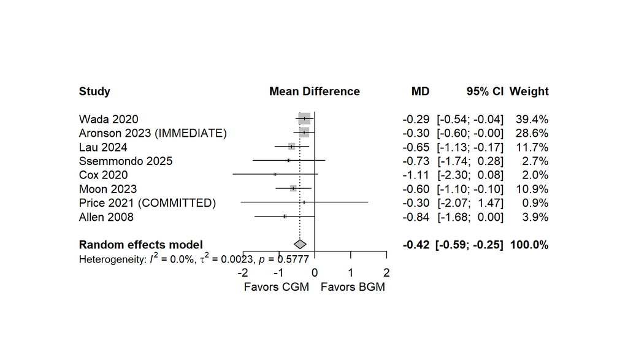

Pooling all 8 trials, CGM was associated with a significantly greater HbA1c reduction than BGM (mean difference **-0.42%**; 95% CI -0.59 to -0.25). Between-study heterogeneity was absent (I² = 0%), though this should be interpreted cautiously given the small number of small trials.

### 4.1 Validation

This pooled estimate is consistent with the published benchmark (−0.37%; 95% CI −0.49 to −0.24), reproducing a peer-reviewed result from the primary data. Minor differences are attributable to the standard-error derivation and missing-data imputation approaches.

## 5 Limitations

Several limitations temper confidence in the pooled estimate. The evidence base is small (8 trials, most with modest sample sizes), limiting the precision of the heterogeneity estimate; an I² of 0% in this setting reflects absence of *detected* heterogeneity rather than strong evidence of consistency. All trials were open-label, raising the possibility of performance and detection bias. Several interventions bundled CGM with structured education or lifestyle programmes, so the pooled effect reflects CGM-plus-support rather than the device in isolation. Finally, six of eight effect estimates were back-calculated; these should be verified against the published forest plot before any formal use.

## 6 References

1. Aronson R, et al. Continuous glucose monitoring in noninsulin-treated type 2 diabetes. *Diabetes Obes Metab.* 2025;27(11):6220–6242.
2. Aronson R, et al. IMMEDIATE trial. *Diabetes Obes Metab.* 2023;25(4):1024–1031.
3. Lau D, Manca DP, Singh P, et al. The effectiveness of continuous glucose monitoring with remote telemonitoring-enabled virtual educator visits in adults with non-insulin dependent type 2 diabetes: a randomized trial. *Diabetes Res Clin Pract.* 2024.
4. Ssemmondo E, Shah N, Newham M, et al. Effect of introduction of intermittently scanned continuous glucose monitoring on glycaemic control in individuals with type 2 diabetes treated with non-insulin therapies. *Diabetes Obes Metab.* 2025;27(3):1226–1232.
5. Cox DJ, Banton T, Moncrief M, et al. Minimizing glucose excursions (GEM) with continuous glucose monitoring in type 2 diabetes: a randomized clinical trial. *J Endocr Soc.* 2020;4(11):bvaa118.
6. Moon SJ, Kim KS, Lee WJ, et al. Efficacy of intermittent short-term use of a real-time continuous glucose monitoring system in non-insulin-treated patients with type 2 diabetes: a randomized controlled trial. *Diabetes Obes Metab.* 2023;25(1):110–120.
7. Price DA, Deng Q, Kipnes M, Beck SE. Episodic real-time CGM use in adults with type 2 diabetes (COMMITTED): results of a pilot randomized controlled trial. *Diabetes Ther.* 2021;12(7):2089–2099.
8. Allen NA, Fain JA, Braun B, Chipkin SR. Continuous glucose monitoring counseling improves physical activity behaviors of individuals with type 2 diabetes: a randomized clinical trial. *Diabetes Res Clin Pract.* 2008;80:371–379.
9. Wada E, Onoue T, Kobayashi T, et al. Flash glucose monitoring helps achieve better glycemic control than conventional self-monitoring of blood glucose in non-insulin-treated type 2 diabetes: a randomized controlled trial. *BMJ Open Diabetes Res Care.* 2020;8(1):e001115.